# HW2

Dmitry Panteleev

2024-05-11

1. (10 points) For the group from golub’s article, experiment with clustering methods: – try different distance metrics (at least 3 types) – then for all distance matrices, test 4 clustering methods and evaluate its quality using coefficient correlation (it is better to automate this process through a function).
2. (10 points) Compare the clustering results with real data and for the best method make a bootstrap (50-100 repetitions).
3. (10 points) Draw meaningful biological conclusions from the data presented

```r
library(glue)
```

```r
library(golubEsets)
library(dplyr)
library(vegan)
library(ggplot2)
library(gridExtra)
library(ape)
library(dendextend)
library(pvclust)
library(tibble)
```

```r
data(Golub_Merge)
#Data to work with
golub <- data.frame(Golub_Merge)[1:7129]
#group vector to check
types_of_cancer <- Golub_Merge$ALL.AML
```

# Practical part

## experiment with clustering methods

```r
rownames(golub) <- paste(rownames(golub),types_of_cancer, sep=" ")
```

### QC

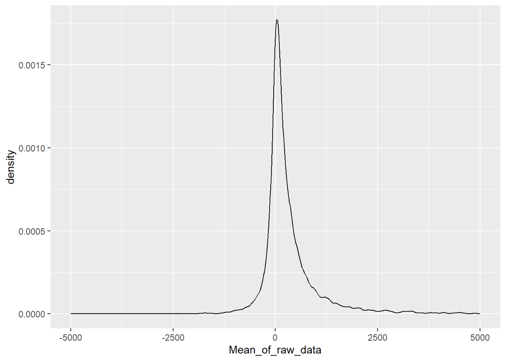

```r
G_mean <- colMeans(golub) %>% as_tibble() %>% arrange(value)

ggplot(G_mean, aes(x=value))+geom_density()+xlab(label = "Mean_of_raw_data")+ xlim(-5000, 5000)
```

```r
dist_eucl <- vegdist(golub, method = "euclidean")
dist_manh <- vegdist(golub, method = "manhattan")
dist_canb <- vegdist(golub, method = "canberra")
```

```r
distance <- data.frame(eucl = as.numeric(dist_eucl), manh = as.numeric(dist_manh), canb = as.numeric(dist_canb))
```

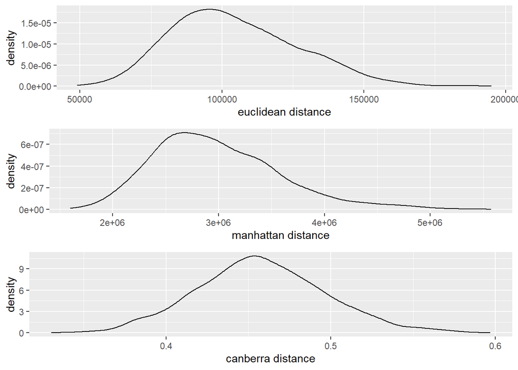

```r
Pl_hist <- ggplot(distance) + geom_density()

Pl_eucl<- Pl_hist + aes(x = eucl)  + labs(x = "euclidean distance")

Pl_manh <- Pl_hist + aes(x = manh) + labs(x = "manhattan distance")

Pl_canb <- Pl_hist + aes(x = canb) + labs(x = "canberra distance")


grid.arrange(Pl_eucl,Pl_manh,Pl_canb)
```

## The Function

test 4 clustering methods and evaluate its quality using coefficient correlation

```r
plot_phulo <- function(d)
{
  hc_single <- hclust(d, method = "single")
  ph_single <- as.phylo(hc_single)
  plot(ph_single, type = "phylogram", cex=0.5, main="single")


  cof_d <- cophenetic(ph_single)
  s_cor <- cor(d, as.dist(cof_d))
  print(glue('cor: {s_cor}, method = "single"'))

  hc_compl <- hclust(d, method = "complete")
  ph_compl <- as.phylo(hc_compl)
  plot(ph_compl, type = "phylogram", cex=0.5, main="complete")

  cof_d <- cophenetic(ph_compl)
  s_cor <- cor(d, as.dist(cof_d))
  print(glue('cor: {s_cor}, method = "complete"'))

  hc_w2 <-hclust(d, method = "ward.D2")
  ph_w2 <- as.phylo(hc_w2)
  plot(ph_w2, type = "phylogram", cex=0.5, main="ward.D2")

  cof_d <- cophenetic(ph_w2)
  s_cor <- cor(d, as.dist(cof_d))
  print(glue('cor: {s_cor}, method = "ward.D2"'))


  hc_av <-hclust(d, method = "average")
  ph_av <- as.phylo(hc_av)
  plot(ph_av, type = "phylogram", cex=0.5, main="average")

  cof_d <- cophenetic(ph_av)
  s_cor <- cor(d, as.dist(cof_d))
  print(glue('cor: {s_cor}, method = "average"'))
}
#
```

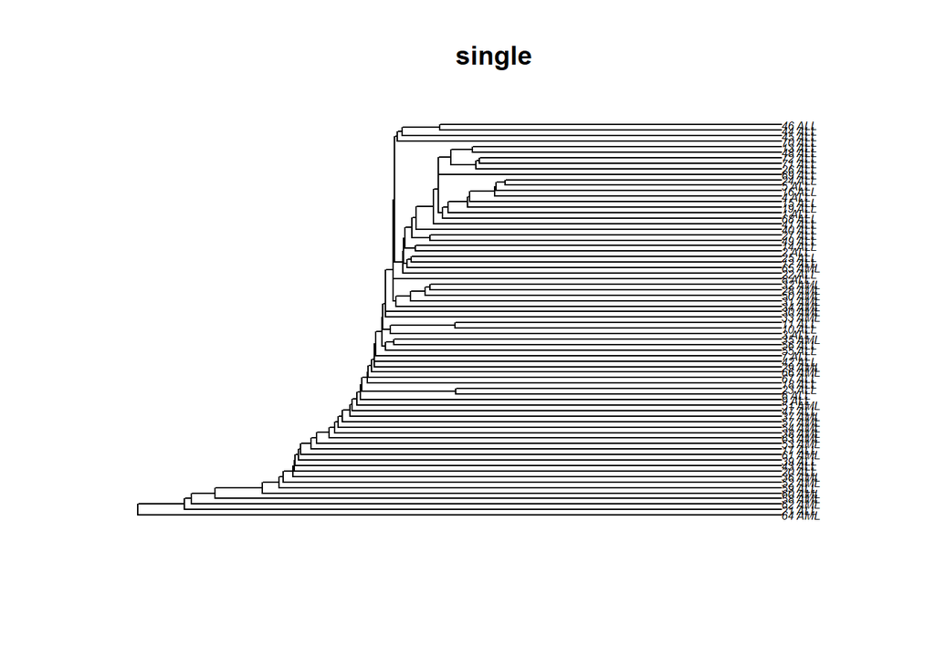

```
## cor: 0.766548345462555, method = "single"
```

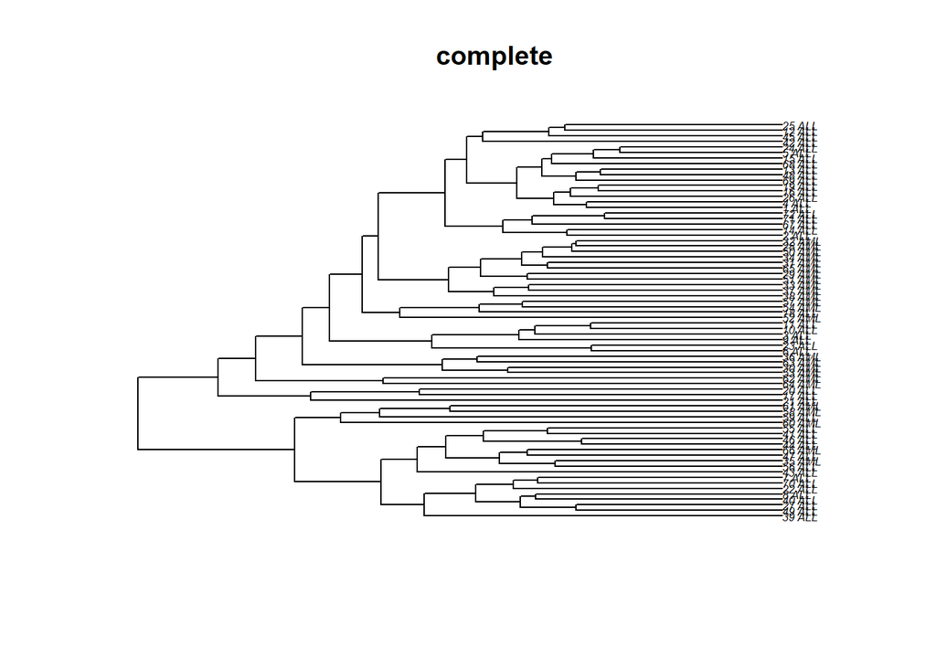

```
## cor: 0.492764109797428, method = "complete"
```

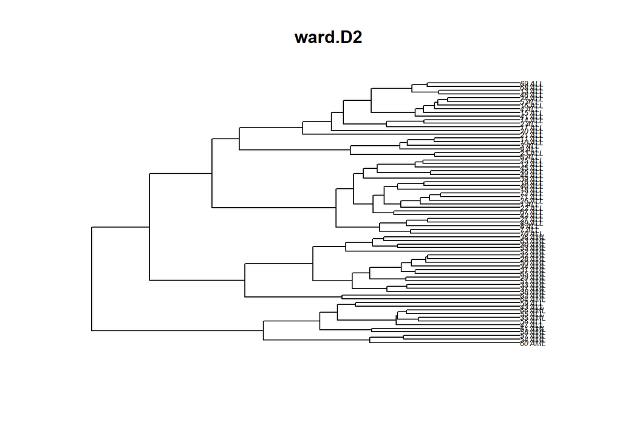

```
## cor: 0.509330230218025, method = "ward.D2"
```

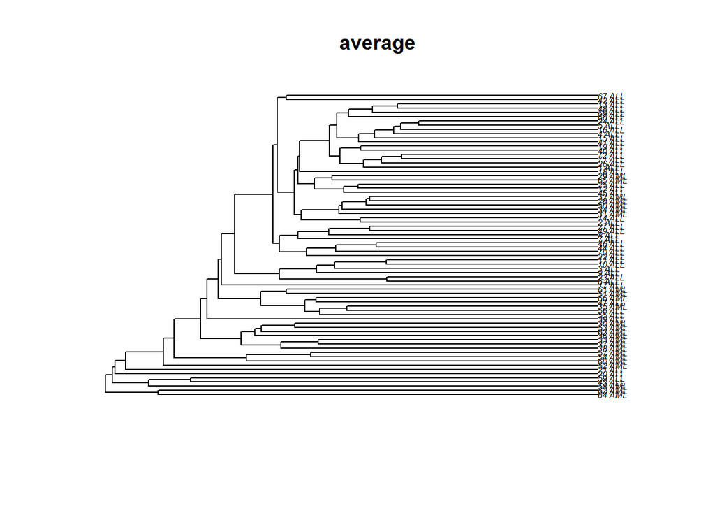

```
## cor: 0.822064198070918, method = "average"
```

```r
plot_phulo(dist_eucl)
```

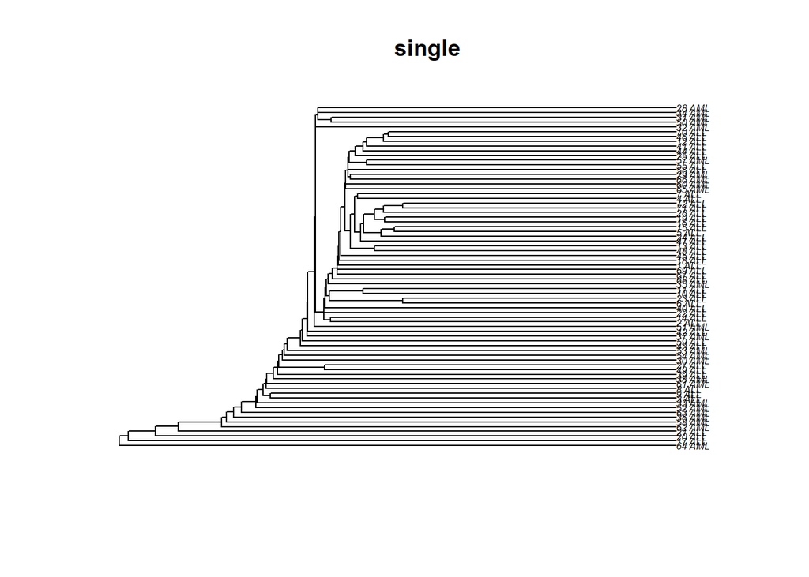

```
## cor: 0.780033181659979, method = "single"
```

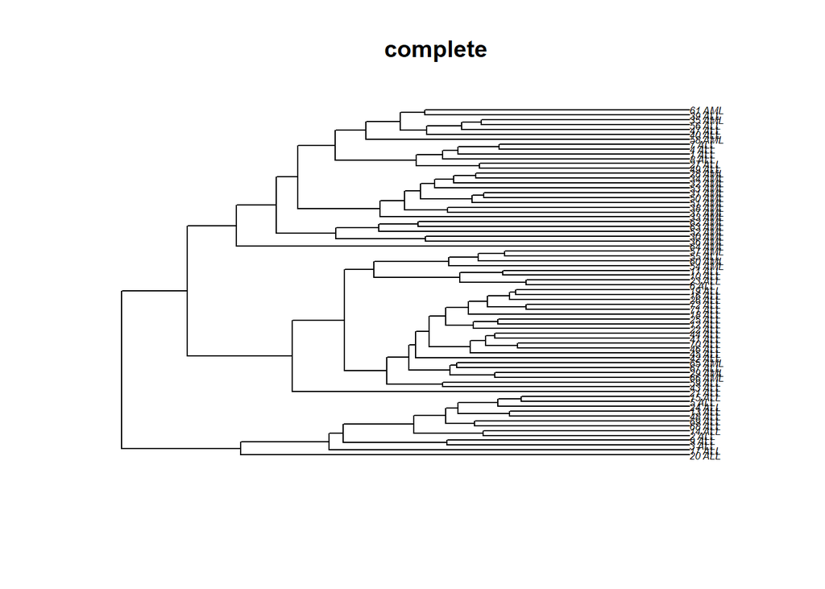

```
## cor: 0.466716475310503, method = "complete"
```

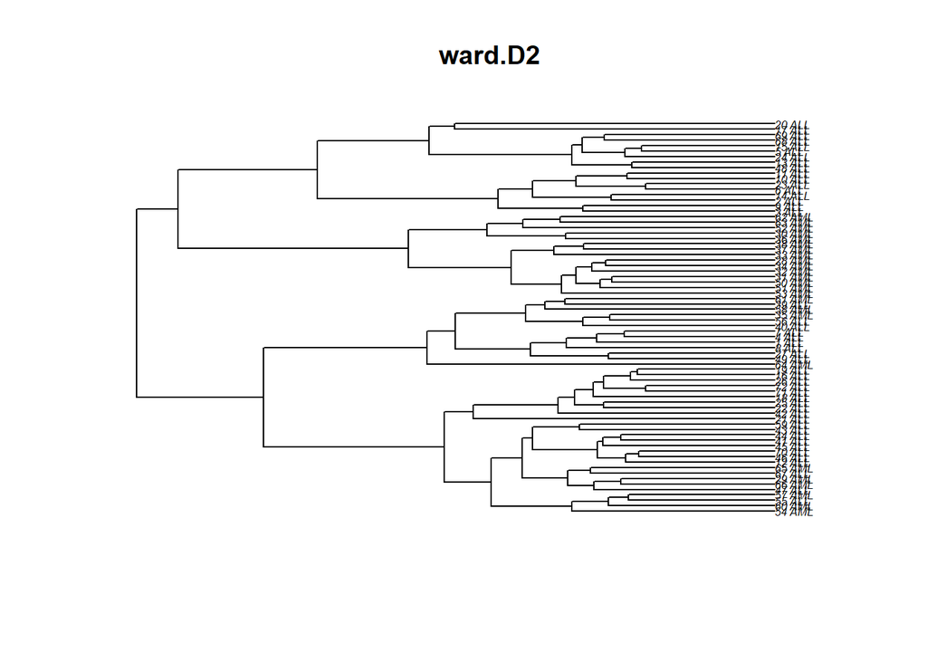

```
## cor: 0.431731685167979, method = "ward.D2"
```

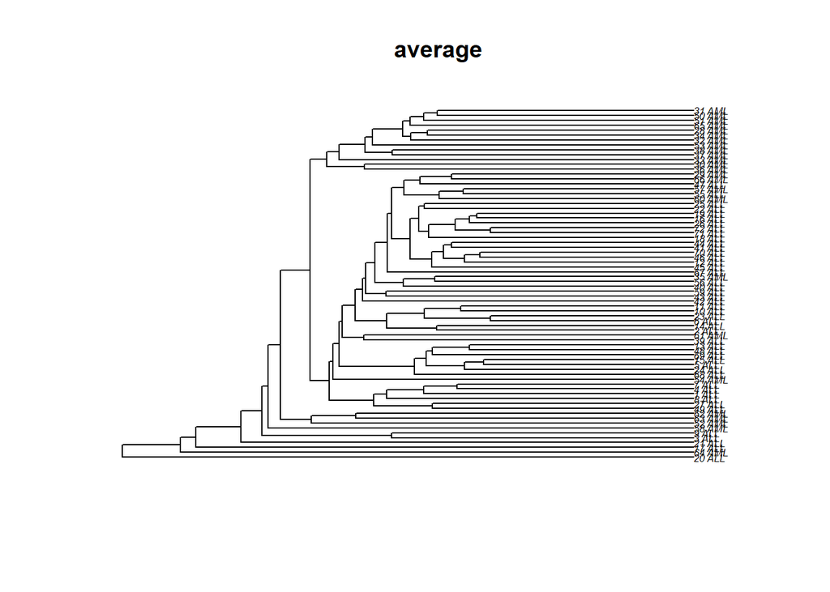

```
## cor: 0.801907483595064, method = "average"
```

```r
plot_phulo(dist_manh)
```

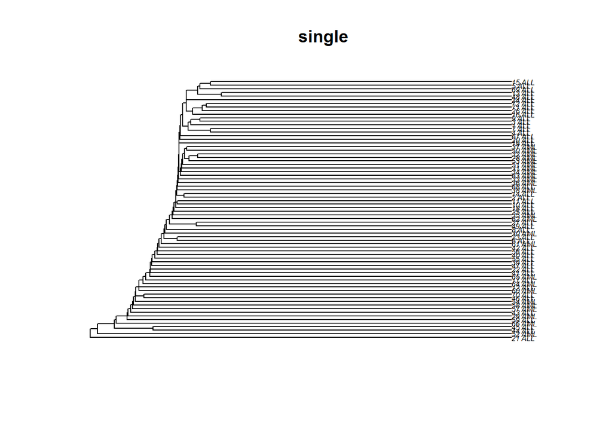

```
## cor: 0.720157044961218, method = "single"
```

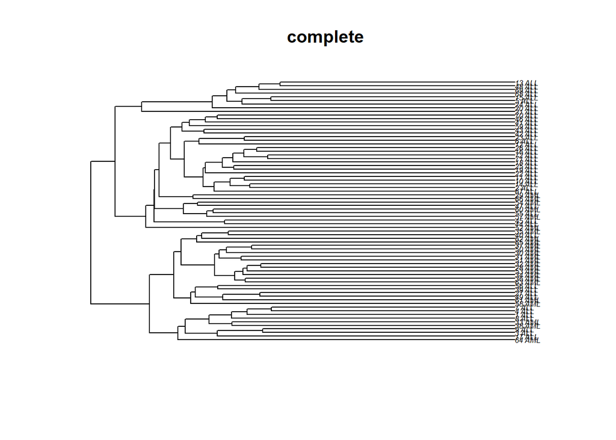

```
## cor: 0.469907063898253, method = "complete"
```

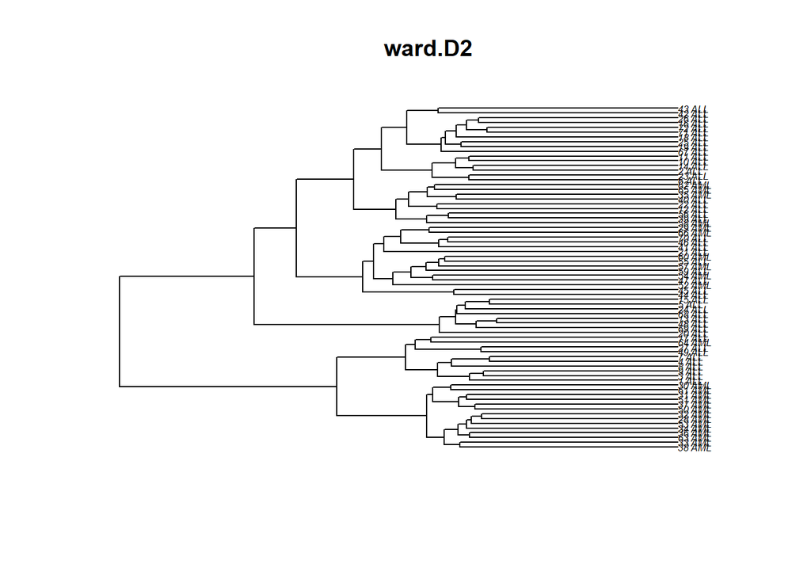

```
## cor: 0.346286354983592, method = "ward.D2"
```

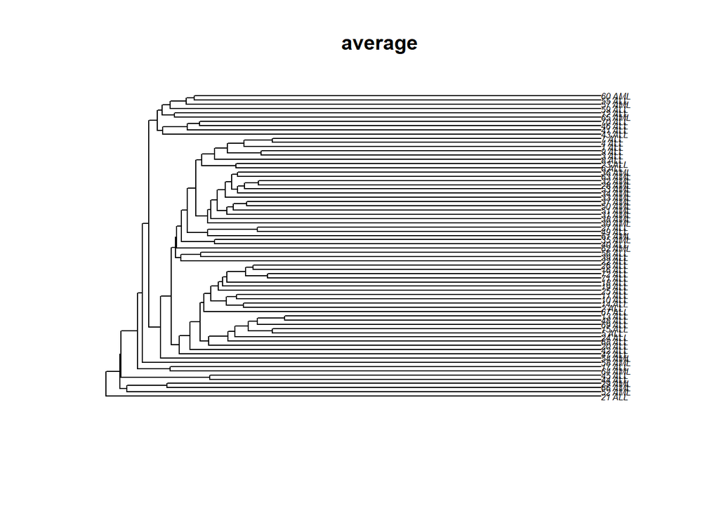

```
## cor: 0.779371915260281, method = "average"
```

```r
plot_phulo(dist_canb)
```

We can see that the best result (coefficient correlation between real distance and the result of clustering, ~0.82) showed the clustering method using the average method with euclidean distance metrics.

```r
cl_boot <- pvclust(t(golub), method.hclust = "average", nboot = 50, method.dist = "euclidean", parallel = TRUE, iseed = 42)
```

```
## Creating a temporary cluster...done:
## кластер-приемник с 11 узлами на хосте 'localhost'
## Multiscale bootstrap... Done.
```

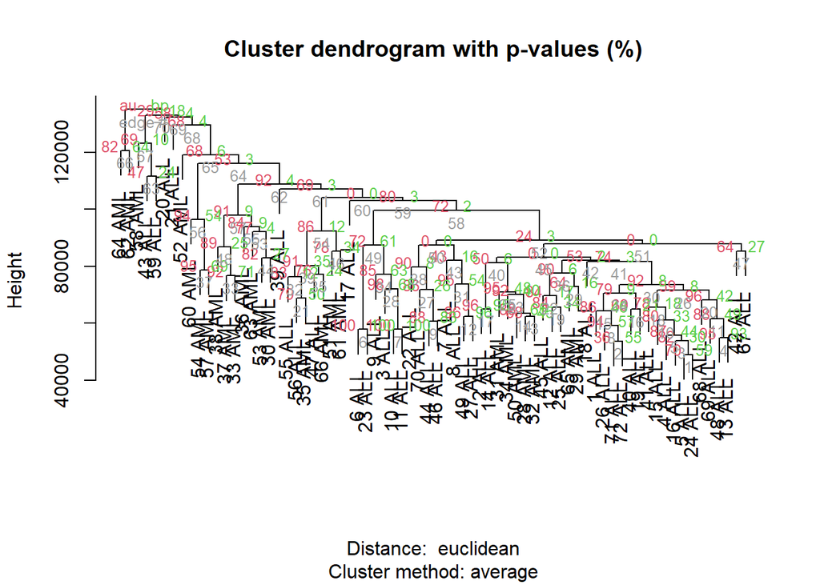

```r
plot(cl_boot)
```

The bootstrap and p-value differ significantly in different steps on the dendrogram. Bootstrap values are pretty low that is why we can doubt about our result, because our result is not stable.  
Also, we do not see certain differences between these types of cancer on the phylogenetic graph, because some of the samples are located inside the tree of a cancer that is not similar to themю